# Open Peer Review

Youri Lam

2023-01-04

For the first part of the assignment I will have to check the reproduction of an article, based on the ‘Repita’ criteria. This criteria are used to check for the reproducibility of scientific research articles. In the table below the different criteria are shown with a definition and the type of response it calls for.

```r
criteria_table <- data.frame(TransparencyCriteria = c("Study Purpose", "Data Availability Statement", "Data Location", "Study Location", "Author Review", "Ethics Statement", "Funding Statement", "Code Availability"),
           Definition = c("A concise statement in the introduction of the article, often in the last paragraph, that establishes the reason the research was conducted. Also called the studyobjective.", "A statement, in an individual section offset from the main body of text, that explains how or if one can access a study’s data. The title of the section may vary, but it must explicitly mention data; it is therefore distinct from a supplementary materials section.", "Where the article’s data can be accessed, either raw or processed.", "Author has stated in the methods section where the study took place or the data’s country/region of origin.", "The professionalism of the contact information that the author has provided in the manuscript.", "A statement within the manuscript indicating any ethical concerns, including the presence of sensitive data.", "A statement within the manuscript indicating whether or not the authors received funding for their research.", "Authors have shared access to the most updated code that they used in their study, including code used for analysis."),
           ResponseType = c("Binary", "Binary", "Found Value", "Binary; Found Value", "Found Value", "Binary", "Binary", "Binary"))

knitr::kable(criteria_table, caption = "Table with the criteria for reproducibility.")
```

Table with the criteria for reproducibility.

| TransparencyCriteria | Definition | ResponseType |
| --- | --- | --- |
| Study Purpose | A concise statement in the introduction of the article, often in the last paragraph, that establishes the reason the research was conducted. Also called the studyobjective. | Binary |
| Data Availability Statement | A statement, in an individual section offset from the main body of text, that explains how or if one can access a study’s data. The title of the section may vary, but it must explicitly mention data; … | Binary |
| Data Location | Where the article’s data can be accessed, either raw or processed. | Found Value |
| Study Location | Author has stated in the methods section where the study took place or the data’s country/region of origin. | Binary; Found Value |
| Author Review | The professionalism of the contact information that the author has provided in the manuscript. | Found Value |
| Ethics Statement | A statement within the manuscript indicating any ethical concerns, including the presence of sensitive data. | Binary |
| Funding Statement | A statement within the manuscript indicating whether or not the authors received funding for their research. | Binary |
| Code Availability | Authors have shared access to the most updated code that they used in their study, including code used for analysis. | Binary |

Using the table previously mentioned, we can go ahead and rank our own article’s reproducibility:

```r
criteria_adhd <- criteria_table %>% mutate(Rating = c("Present", "Present", "Present, the data can be found [here](https://figshare.com/articles/dataset/SHR/5091727)", "The workplace of the authors has been given (Taiwan), but the location where the research has been performed remains unnamed.", "Only 2 of the authors' email adresses have been given, the others are not able to be contacted", "Not present", "Present", "Not present"))

knitr::kable(criteria_adhd, caption = "Table showing how the article scored on reproducibility.")
```

Table showing how the article scored on reproducibility.

| TransparencyCriteria | Definition | ResponseType | Rating |
| --- | --- | --- | --- |
| Study Purpose | A concise statement in the introduction of the article, often in the last paragraph, that establishes the reason the research was conducted. Also called the studyobjective. | Binary | Present |
| Data Availability Statement | A statement, in an individual section offset from the main body of text, that explains how or if one can access a study’s data. The title of the section may vary, but it must explicitly mention data; … | Binary | Present |
| Data Location | Where the article’s data can be accessed, either raw or processed. | Found Value | Present, the data can be found [here](https://figshare.com/articles/dataset/SHR/5091727) |
| Study Location | Author has stated in the methods section where the study took place or the data’s country/region of origin. | Binary; Found Value | The workplace of the authors has been given (Taiwan), but the location where the research has been performed remains unnamed. |
| Author Review | The professionalism of the contact information that the author has provided in the manuscript. | Found Value | Only 2 of the authors’ email adresses have been given, the others are not able to be contacted |
| Ethics Statement | A statement within the manuscript indicating any ethical concerns, including the presence of sensitive data. | Binary | Not present |
| Funding Statement | A statement within the manuscript indicating whether or not the authors received funding for their research. | Binary | Present |
| Code Availability | Authors have shared access to the most updated code that they used in their study, including code used for analysis. | Binary | Not present |

Overall, I give this article a 8.5/10 on reproducibility. It’s clear what the writers of this article want to put forward, even if no code is provided.

For the second part of the assignment I will have to use the code provided with an article. I will have to try and understand the code, explain what it does and even try to make at least one figure.

Link to the article: https://osf.io/wqc25/ The code is easily available and very easily readable. There are a lot of codes included. Using the processed data, it is very easy to recreate on of the figures from this study. I would rate the readabilty of this code a 5/5.

```r
# gg_color_hue ------------------------------------------------------------

## function for colors
gg_color_hue <- function(n) {
  hues = seq(15, 375, length = n + 1)
  hcl(h = hues, l = 65, c = 100)[1:n]
}

# get_max_daily -----------------------------------------------------------

# x <- ymd("2020-03-23 UTC")
get_max_daily <- function(x){
  x <- x + c(1:4, 9:12, 17:20, 25:27)
  x <- x[x < ymd("2020-04-13 UTC")]
  return(x)
}

# read data ---------------------------------------------------------------

# sample 1
sample1 <- read.csv(here("raw_data/sample1_use for revision 1.csv"))
sample1 <- sample1[sample1$include_1,]

# sample 2
sample2 <- read.csv(here("raw_data/sample2_use for revision 1.csv"))
sample2 <- sample2[sample2$include_1,]

# combine samples for the additional analyses
data <- rbind(sample1, sample2)

# packages ----------------------------------------------------------------

# install.packages("lubridate")
library(lubridate)
# -------------------------------------------------------------------------

## define colors
c <- gg_color_hue(2)
col.s1 <- c[1]
col.s2 <- c[2]

# completed baseline surveys per day that are included in the study
data_l2_s1 <- unique(sample1[c("ID", "b_baseline_ended")])
data_l2_s2 <- unique(sample2[c("ID", "b_baseline_ended")])

# no missings on this variable
any(is.na(data_l2_s1[2]))
```

```
## [1] FALSE
```

```r
any(is.na(data_l2_s2[2]))
```

```
## [1] FALSE
```

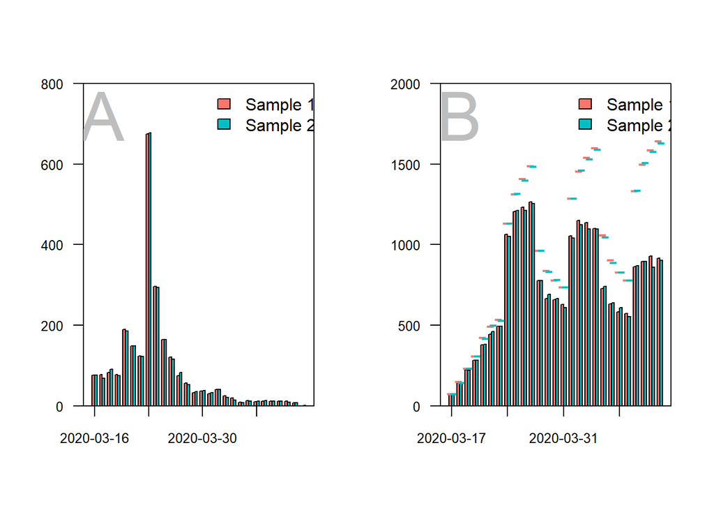

```r
date_s1 <- ymd_hms(data_l2_s1$b_baseline_ended)
hour(date_s1) <- 0
minute(date_s1) <- 0
second(date_s1) <- 0

date_s2 <- ymd_hms(data_l2_s2$b_baseline_ended)
hour(date_s2) <- 0
minute(date_s2) <- 0
second(date_s2) <- 0


# number of baseline surveys completed
t_date_baseline_1 <- table(ymd(date_s1))
t_date_baseline_2 <- table(ymd(date_s2))
t_date_baseline_1 <- c(t_date_baseline_1, "2020-04-12" = 0)
t_date_baseline_12 <- rbind(t_date_baseline_1, t_date_baseline_2)

# barplot sample 1 and 2 baseline participation ---------------------------

layout(matrix(1:2, 1, 2, byrow = TRUE))

b <- barplot(t_date_baseline_12, beside = TRUE, ylim = c(0, 800), names.arg = rep("", length(t_date_baseline_12)),
             col = c(col.s1, col.s2), axes = FALSE)
box()
axis(2, las = 2, cex.axis = 0.8)
s <- seq(1, 28, 7)
labels <- colnames(t_date_baseline_12)[s]
axis(1, at = ((b[1,] + b[2,])/2)[s], labels = labels, cex.axis = 0.8)
text("A", x = ((b[1,] + b[2,])/2)[2], y = 800*.9, cex = 4, col = "grey")
legend(x = ((b[1,] + b[2,])/2)[15], y = 800, legend = c("Sample 1", "Sample 2"), fill = c(col.s1, col.s2), bty = "n")


# dates at which a daily survey could have been completed:
max_daily_dates_s1 <- lapply(ymd(date_s1), get_max_daily)
max_daily_dates_s2 <- lapply(ymd(date_s2), get_max_daily)

max_dates_s1 <- do.call("c", max_daily_dates_s1)
max_dates_s2 <- do.call("c", max_daily_dates_s2)
obtained_dates_s1 <- sample1$daily_date
obtained_dates_s2 <- sample2$daily_date

t_max_dates_s1 <- table(max_dates_s1)
t_max_dates_s2 <- table(max_dates_s2)

t_obtained_dates_s1 <- table(obtained_dates_s1)
t_obtained_dates_s2 <- table(obtained_dates_s2)

t_obtained_dates_s12 <- rbind(t_obtained_dates_s1, t_obtained_dates_s2)

b <- barplot(t_obtained_dates_s12, beside = TRUE, ylim = c(0, 2000),
             names.arg = rep("", length(t_obtained_dates_s12)),
             col = c(col.s1, col.s2), axes = FALSE)
box()
axis(2, las = 2, cex.axis = 0.8)
labels <- colnames(t_obtained_dates_s12)[s]
axis(1, at = ((b[1,] + b[2,])/2)[s], labels = labels, cex.axis = 0.8)

lines(y = t_max_dates_s1, x = b[1,], type = "p", pch = "-", col = col.s1, cex = 1.5)
lines(y = t_max_dates_s2, x = b[2,], type = "p", pch = "-", col = col.s2, cex = 1.5)
text("B", x = ((b[1,] + b[2,])/2)[2], y = 2000*.9, cex = 4, col = "grey")
legend(x = ((b[1,] + b[2,])/2)[15], y = 2000, legend = c("Sample 1", "Sample 2"), fill = c(col.s1, col.s2), bty = "n")
```

I didn’t have any trouble reading the code, or understanding what needed to happen. The only error I got was in the read.csv function (lines 70 & 74). To fix this. I redirected the function with the ‘here’ command. That way, it was able to find the files in the raw_data folder.